# Airport Waiting Times

Bret Larget

This R Markdown document includes contributions from Professor Jessi Kehe.

## Function to read in waiting time data

```r
## Input:  x = HTML file
## Output: nicely formatted tibble
read_airport =  function(x)
{
  airport_column_names = c("airport",
                           "terminal",
                           "date",
                           "hour",
                           "us_avg_wait",
                           "us_max_wait",
                           "non_us_avg_wait",
                           "non_us_max_wait",
                           "all_avg_wait",
                           "all_max_wait",
                           "all_n_0_15",
                           "all_n_16_30",
                           "all_n_31_45",
                           "all_n_46_60",
                           "all_n_61_90",
                           "all_n_91_120",
                           "all_n_120_plus",
                           "all_excluded",
                           "all_total",
                           "all_flights",
                           "all_booths")

  airport = readHTMLTable(x)$`NULL` %>%
    slice(-(1:3))

  names(airport) = airport_column_names

  airport = airport %>%
    as_tibble() %>%
    mutate(across(ends_with("wait") | starts_with("all"), as.numeric)) %>%
    mutate(across(where(is.factor),as.character)) %>%
    mutate(date = mdy(date))

  return( airport )
}
```

## Read the Data

```r
## read the individual data sets
den = read_airport("../../data/DEN-2018.html")
jfk = read_airport("../../data/JFK-2018.html")
lax = read_airport("../../data/LAX-2018.html")
msp = read_airport("../../data/MSP-2018.html")
ord = read_airport("../../data/ORD-2018.html")
sfo = read_airport("../../data/SFO-2018.html")

## combine into one data set
awt = bind_rows(den, jfk, lax, msp, ord, sfo)

## remove the individual ones
rm(den, jfk, lax, msp, ord, sfo)
```

## Questions

1. Are some airports more efficient that than others in terms of average wait time?
   - Are some airports more efficient in the number of people served by hour per available booth?
2. Are some months busier than others?
   - Are some days of the week busier than others?
   - Are some times during the day busier than others?
3. How does the proportion of people who get through customs in less than 30 minutes depend on other factors?

## Airport efficiency

> Are some airports more efficient than others in terms of average wait time?

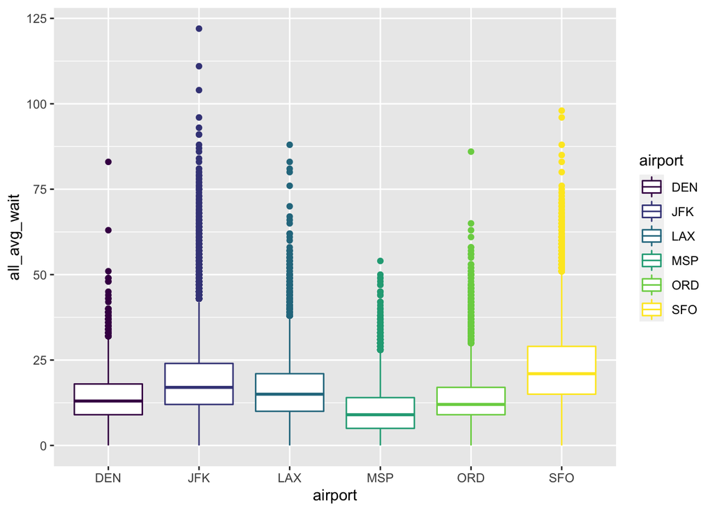

```r
ggplot(awt, aes(x=airport, y=all_avg_wait, color=airport)) +
  geom_boxplot()
```

- We can adjust the plot by reordering the airports in descending order by the median of their average waiting time for all passengers.
- Here, I do not save the reordering of the airports
- The modified data set is piped into `ggplot()`

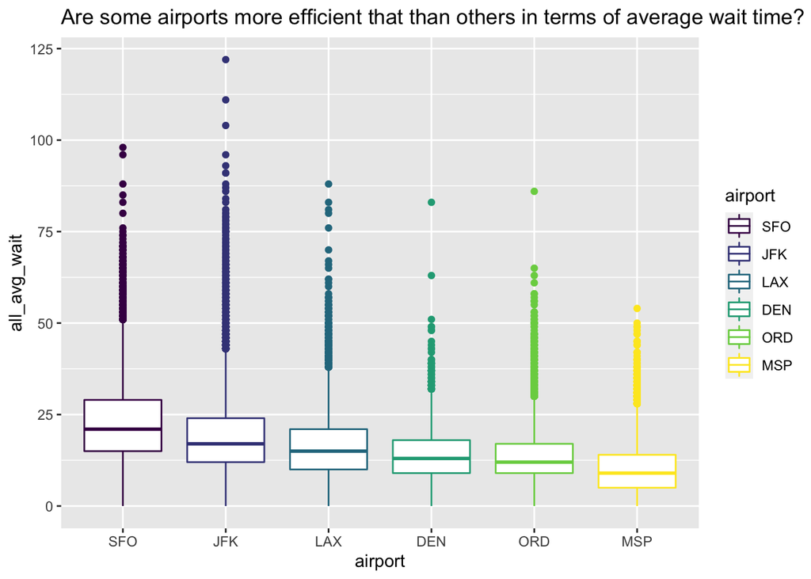

```r
awt %>%
  mutate(airport = reorder(airport,-all_avg_wait, FUN=median)) %>%
  #`airport` as factor with levels ordered according to -all_avg_wait and FUN value
  ggplot(aes(x=airport, y=all_avg_wait, color=airport)) +
  geom_boxplot() +
  ggtitle("Are some airports more efficient that than others in terms of average wait time?")
```

> Are some airports more efficient in the number of people served by hour per available booth?
- Calculate the average number of people served per hour per booth
- There are a few ways to consider how to calculate this
- Here, we do the calculation separately for each airport and hour during the day
  - We then calculate the total number of passengers and the total number of booths each hour, then divide
- An alternative could be to calculate the rate for row of the data set and then to find the average (or median) of these rates  
  ### method 1

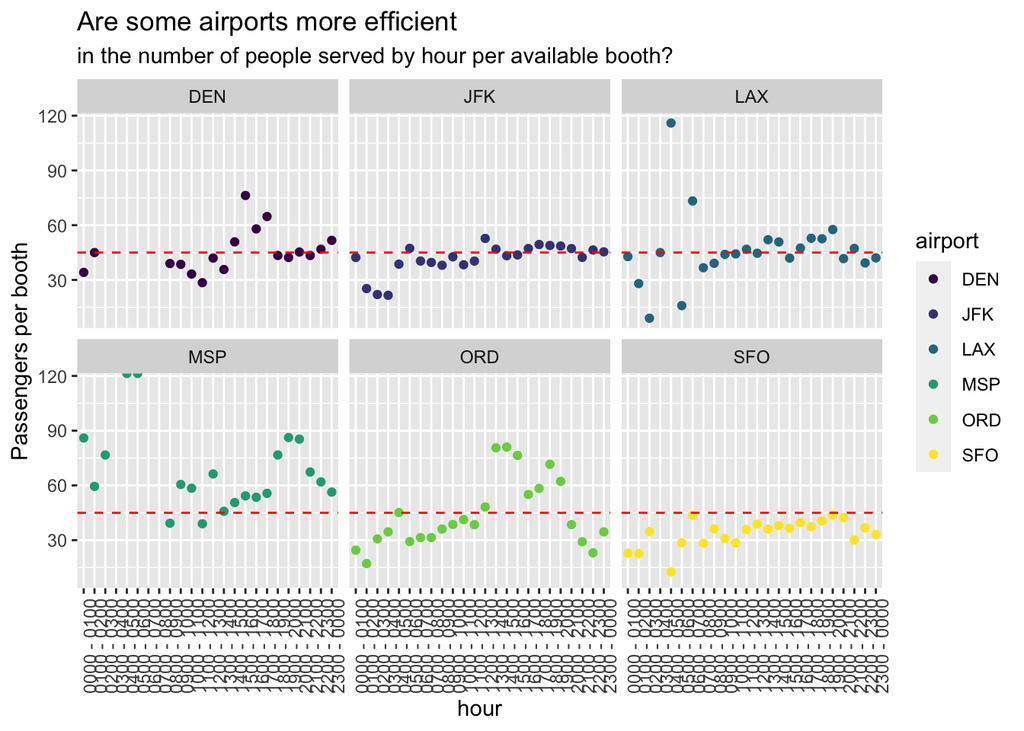

```r
awt %>%
  group_by(airport, hour) %>%
  summarize(total = sum(all_total),
            booth_total = sum(all_booths)) %>%
  mutate(per_booth = round(total/booth_total,2)) %>%
  select(-total, -booth_total) %>%
  ggplot(aes(hour, per_booth, color=airport)) +
  geom_point() +
  geom_hline(yintercept=45, linetype="dashed",color="red") +
  facet_wrap(~airport) +
  theme(axis.text.x = element_text(angle = 90, hjust = 1)) +
  ylab("Passengers per booth") +
  ggtitle("Are some airports more efficient",
          subtitle = "in the number of people served by hour per available booth?")
```

- There do appear to be differences between the efficiency (in terms of passengers per booth per hour) among the airports.
- For example, MSP seems to be more efficient (in the noted sense) regularly serving more than 45 passengers per booth per hour.
- SFO seems to serve fewer than 45 passengers per booth per hour most of the time.

### Second method

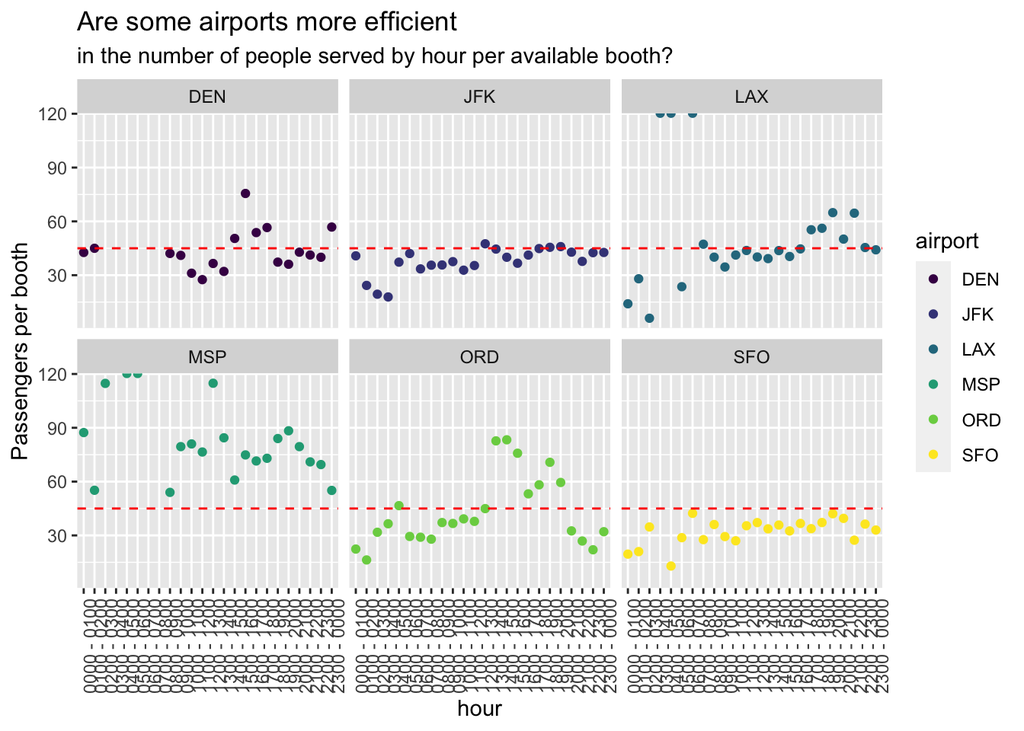

```r
awt %>%
  mutate(rate = all_total / all_booths) %>%
  group_by(airport, hour) %>%
  summarize(rate_mean = mean(rate),
            rate_median = median(rate)) %>%
  ggplot(aes(x = hour, y = rate_median, color=airport)) +
  geom_point() +
  geom_hline(yintercept = 45,
             linetype = "dashed", color = "red") +
  facet_wrap(~ airport) +
  theme(axis.text.x = element_text(angle = 90, hjust = 1)) +
  ylab("Passengers per booth") +
  ggtitle("Are some airports more efficient",
          subtitle = "in the number of people served by hour per available booth?")
```

## Busy times

> Are some months busier than others?
- Begin by adding a month variable and then reordering the columns
- Also add weekday for future use

```r
awt = awt %>%
  mutate(month = month(date, label = TRUE),
         wday = wday(date, label = TRUE)) %>%
  select(airport, terminal, date, month, everything())
```

- Count the total number of passengers by month and sort.

```r
awt %>%
  group_by(month) %>%
  summarize(total = sum(all_total)) %>%
  arrange(desc(total))
```

```
## # A tibble: 12 × 2
##    month   total
##    <ord>   <dbl>
##  1 Jul   4313581
##  2 Aug   4244065
##  3 Jun   3737710
##  4 Sep   3510723
##  5 Apr   3475220
##  6 Oct   3393282
##  7 Mar   3356425
##  8 May   3337989
##  9 Jan   3249648
## 10 Dec   3145717
## 11 Nov   3020660
## 12 Feb   2646150
```

- The previous summary is affected by different numbers of days in each month.
- Calculate the average daily rate of passengers by month.
- (Recall that May has only 30 observations.)
- Key idea here is to first summarize by month and day, and then by month, in order to get the total number of passengers in each month and the number of days in each month.

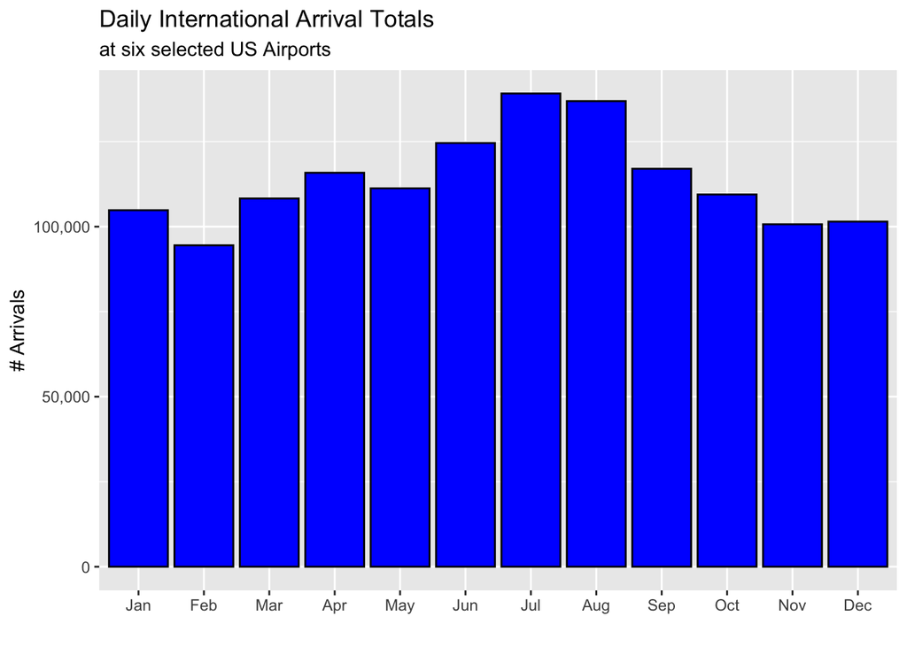

```r
busy_months = awt %>%
  mutate(day = day(date)) %>%
  group_by(month, day) %>%
  summarize(total = sum(all_total)) %>%
  group_by(month) %>%
  summarize(n = n(), total = sum(total), daily = total/n) %>%
  arrange(desc(daily))

ggplot(busy_months, aes(x=month, y=daily)) +
  geom_col(fill = "blue", color = "black") +
  scale_y_continuous(labels = comma) +
  xlab("") +
  ylab("# Arrivals") +
  ggtitle("Daily International Arrival Totals", subtitle = "at six selected US Airports")
```

- It looks like the summer months (July, August, June) are the busiest in terms of number of passengers traveling per day for the airports in our data.

> Are some days of the week busier than others?

```r
# We first need to count the number of each day of the week in 2018
busy_wdays = awt %>%
  group_by(date, wday) %>%
  summarize(total = sum(all_total)) %>%
  group_by(wday) %>%
  summarize(n=n(), total = sum(total))  %>%
  mutate(daily=round(total/n,2)) %>%
  arrange(desc(daily))
busy_wdays
```

```
## # A tibble: 7 × 4
##   wday      n   total   daily
##   <ord> <int>   <dbl>   <dbl>
## 1 Sat      52 6544126 125849.
## 2 Sun      52 6366261 122428.
## 3 Mon      53 6121230 115495.
## 4 Fri      52 5833805 112189.
## 5 Thu      52 5628670 108244.
## 6 Wed      52 5532535 106395.
## 7 Tue      51 5404543 105971.
```

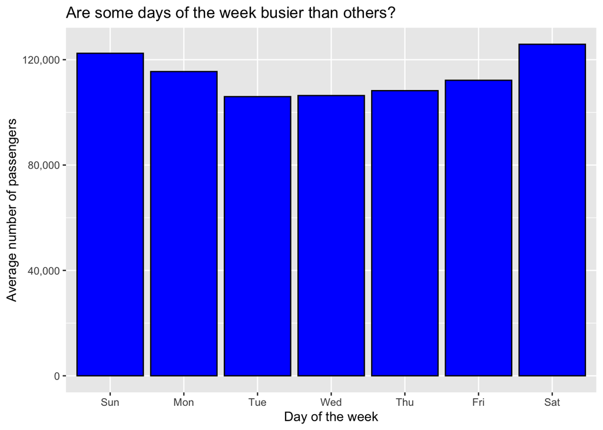

```r
ggplot(busy_wdays, aes(x = wday, y = daily)) +
  geom_col(fill = "blue", color = "black") +
  scale_y_continuous(labels = comma) +
  xlab("Day of the week") +
  ylab("Average number of passengers") +
  ggtitle("Are some days of the week busier than others?")
```

> Are some times during the day busier than others?

```r
busy_times = awt %>%
  group_by(date, hour) %>%
  summarize(total = sum(all_total)) %>%
  group_by(hour) %>%
  summarize(n = n(), total = sum(total))  %>%
  mutate(hourly = round(total/n,2)) %>%
  arrange(desc(hourly))
busy_times
```

```
## # A tibble: 24 × 4
##    hour            n   total hourly
##    <chr>       <int>   <dbl>  <dbl>
##  1 1300 - 1400   364 3378614  9282.
##  2 1400 - 1500   364 3187415  8757.
##  3 1500 - 1600   364 3177401  8729.
##  4 1200 - 1300   364 3092218  8495.
##  5 1600 - 1700   364 3043461  8361.
##  6 1700 - 1800   364 2913956  8005.
##  7 1800 - 1900   364 2799314  7690.
##  8 1900 - 2000   364 2700282  7418.
##  9 1100 - 1200   364 2165588  5949.
## 10 2000 - 2100   364 2001425  5498.
## # … with 14 more rows
```

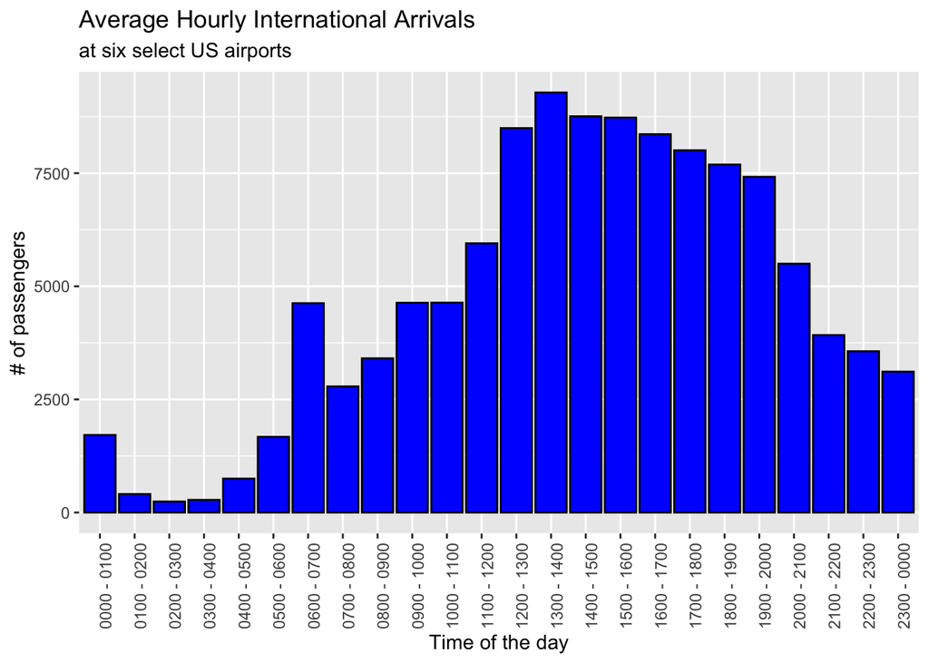

```r
ggplot(busy_times, aes(x = hour, y = hourly)) +
  geom_col(fill = "blue", col = "black") +
  theme(axis.text.x = element_text(angle = 90, hjust = 1))  +
  xlab("Time of the day") +
  ylab("# of passengers") +
  ggtitle("Average Hourly International Arrivals", subtitle = "at six select US airports")
```

## Getting through customs quickly

> How does the proportion of people who get through customs in less than 30 minutes depend on other factors?

```r
## Add columns for proportion less than 30 minutes and proportion more than an hour
awt = awt %>%
  mutate(p_less_30 = (all_n_0_15 + all_n_16_30) / all_total,
         p_more_60 = (all_n_61_90 + all_n_91_120 + all_n_120_plus) / all_total)
```

#### Factor: Airport

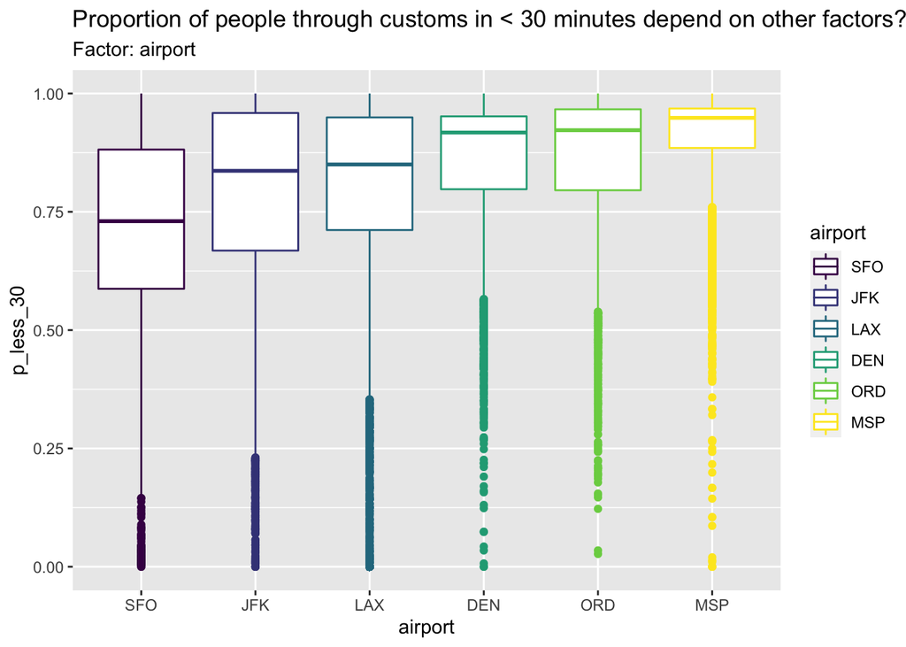

```r
awt %>%
  mutate(airport = reorder(airport,p_less_30,FUN=median)) %>%
ggplot(aes(x=airport,y=p_less_30,color=airport)) +
  geom_boxplot() +
  ggtitle("Proportion of people through customs in < 30 minutes depend on other factors?",
          subtitle = "Factor: airport")
```

#### Factor: Hour

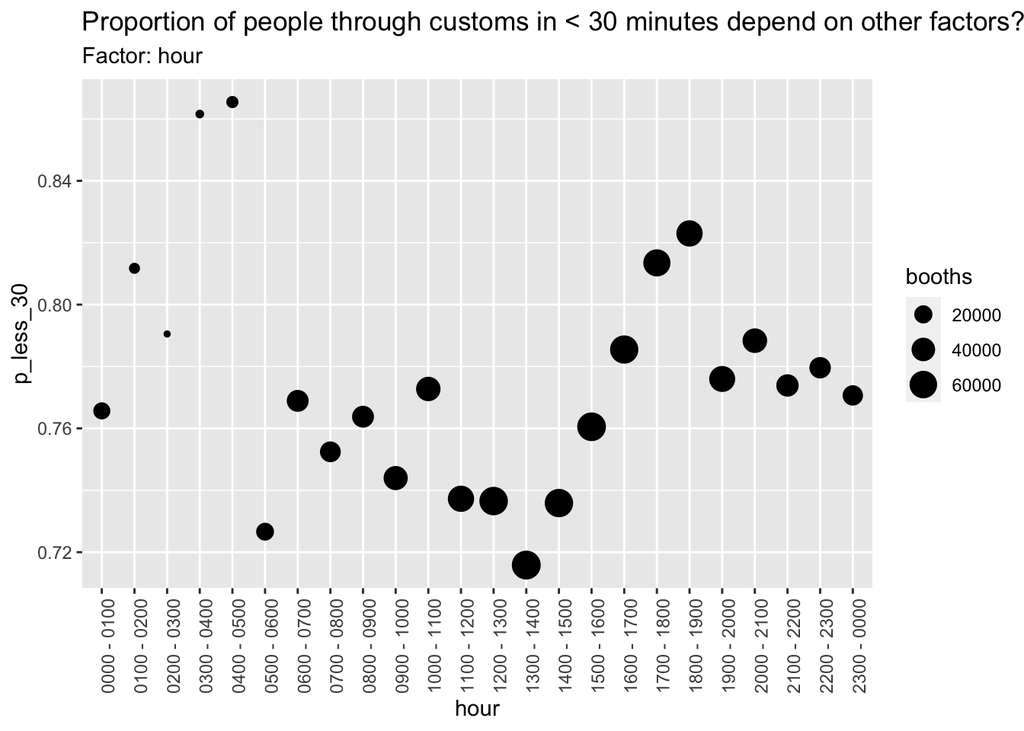

```r
## Fraction of passengers per hour that go through in < 30 minutes
awt %>%
  group_by(hour) %>%
  summarize(total = sum(all_total),
          n_less_30 = sum(all_n_0_15) + sum(all_n_16_30),
          p_less_30 = n_less_30 / total,
          booths = sum(all_booths)) %>%
  ggplot(aes(hour,p_less_30, size = booths)) +
  geom_point() +
  theme(axis.text.x = element_text(angle = 90, hjust = 1)) +
  ggtitle("Proportion of people through customs in < 30 minutes depend on other factors?",
          subtitle = "Factor: hour")
```

#### Factor: Airport and Hour

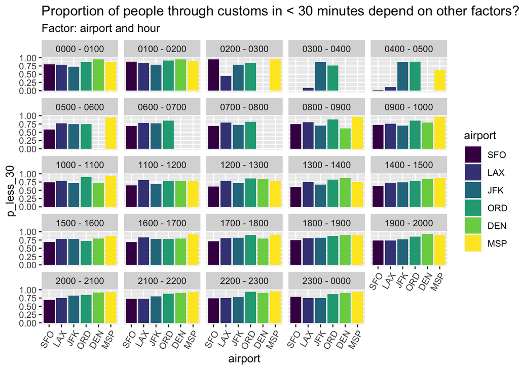

```r
## Fraction of passengers per airport and per hour that go through in < 30 minutes
awt %>%
  group_by(airport,hour) %>%
  summarize(total = sum(all_total),
            n_less_30 = sum(all_n_0_15) + sum(all_n_16_30),
            p_less_30 = n_less_30 / total,
            booths = sum(all_booths)) %>%
  ungroup() %>% ## airport is a grouping variable and cannot be mutated
  mutate(airport = reorder(airport,p_less_30,FUN=mean)) %>%
  ggplot(aes(x=airport, y=p_less_30,fill=airport)) +
  geom_col() +
  facet_wrap(~hour) +
  theme(axis.text.x = element_text(angle = 60, hjust = 1)) +
  ggtitle("Proportion of people through customs in < 30 minutes depend on other factors?",
          subtitle = "Factor: airport and hour")
```

```r
# It looks like some of the airports do not have passengers in certain time windows
# Is that correct?
awt %>%
  filter(airport=="MSP") %>%
  group_by(hour) %>%
  summarize(tot = sum(all_total))
```

```
## # A tibble: 21 × 2
##    hour           tot
##    <chr>        <dbl>
##  1 0000 - 0100   8858
##  2 0100 - 0200    892
##  3 0200 - 0300    460
##  4 0400 - 0500     11
##  5 0500 - 0600     35
##  6 0800 - 0900  18578
##  7 0900 - 1000  10108
##  8 1000 - 1100  10580
##  9 1100 - 1200  51759
## 10 1200 - 1300 169542
## # … with 11 more rows
```

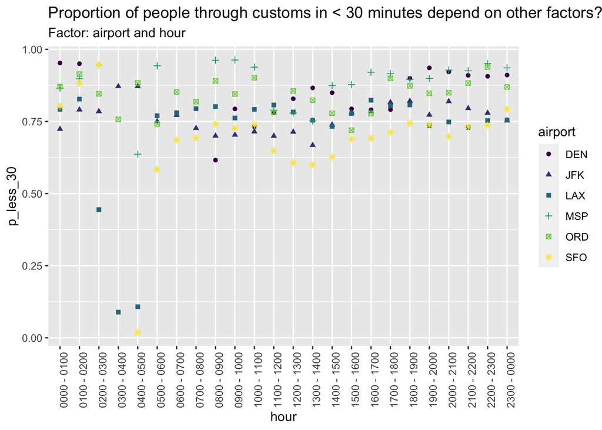

```r
## Let's try a scatterplot of the same information as the previous graphic
## -> which is easier to interpret?
## Fraction of passengers per airport and per hour that go through in < 30 minutes
awt %>%
  group_by(airport,hour) %>%
  summarize(total = sum(all_total),
            n_less_30 = sum(all_n_0_15) + sum(all_n_16_30),
            p_less_30 = n_less_30 / total,
            booths = sum(all_booths)) %>%
  ggplot(aes(x=hour, y=p_less_30,color=airport, shape=airport)) +
  geom_point() +
  # facet_wrap(~airport) +
  # geom_hline(yintercept=0.8, color="red", linetype="dashed") +
  theme(axis.text.x = element_text(angle = 90, hjust = 1)) +
  ggtitle("Proportion of people through customs in < 30 minutes depend on other factors?",
          subtitle = "Factor: airport and hour")
```

#### Factor: Number of Booths and Hour

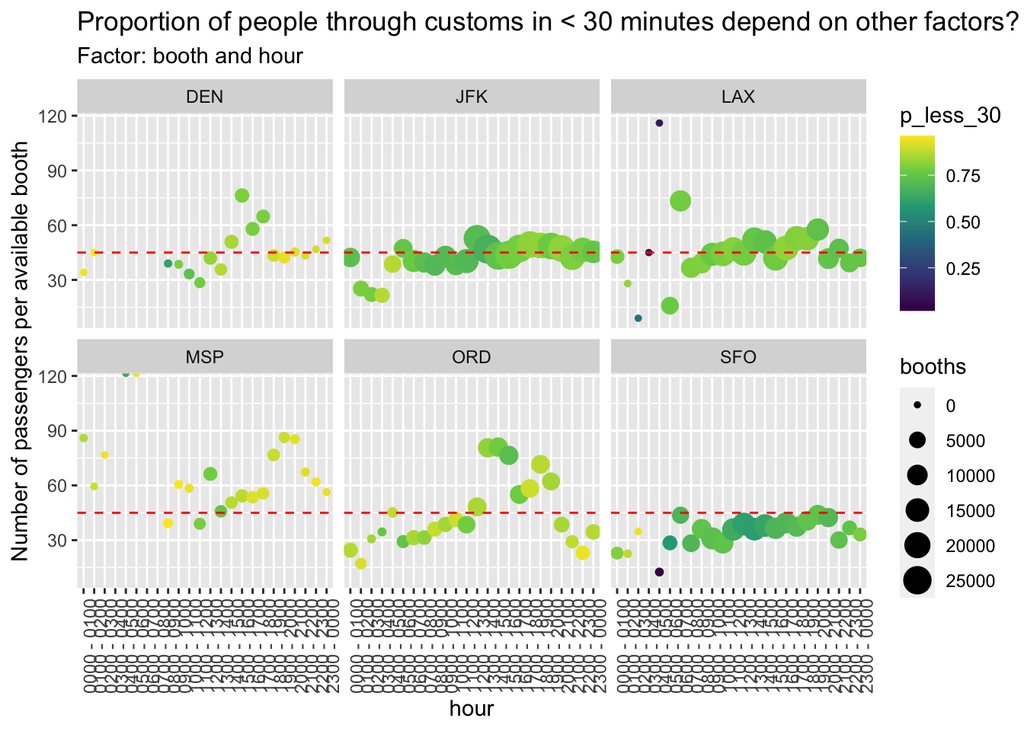

```r
# Look at passengers per booth vs. hour
# Color based on proportion who wait less than 30 minutes
# Consider size based on the number of booths open
awt %>%
  group_by(airport,hour) %>%
  summarize(total = sum(all_total),
            n_less_30 = sum(all_n_0_15) + sum(all_n_16_30),
            p_less_30 = n_less_30 / total,
            booths = sum(all_booths)) %>%
  mutate(passenger_per_booth = total/booths) %>%
  ggplot(aes(hour,passenger_per_booth, color=p_less_30, size = booths)) +
  geom_point() +
  geom_hline(yintercept=45, color="red", linetype="dashed") +
  facet_wrap(~airport) +
  ylab("Number of passengers per available booth") +
  theme(axis.text.x = element_text(angle = 90, hjust = 1)) +
  ggtitle("Proportion of people through customs in < 30 minutes depend on other factors?",
          subtitle = "Factor: booth and hour")
```

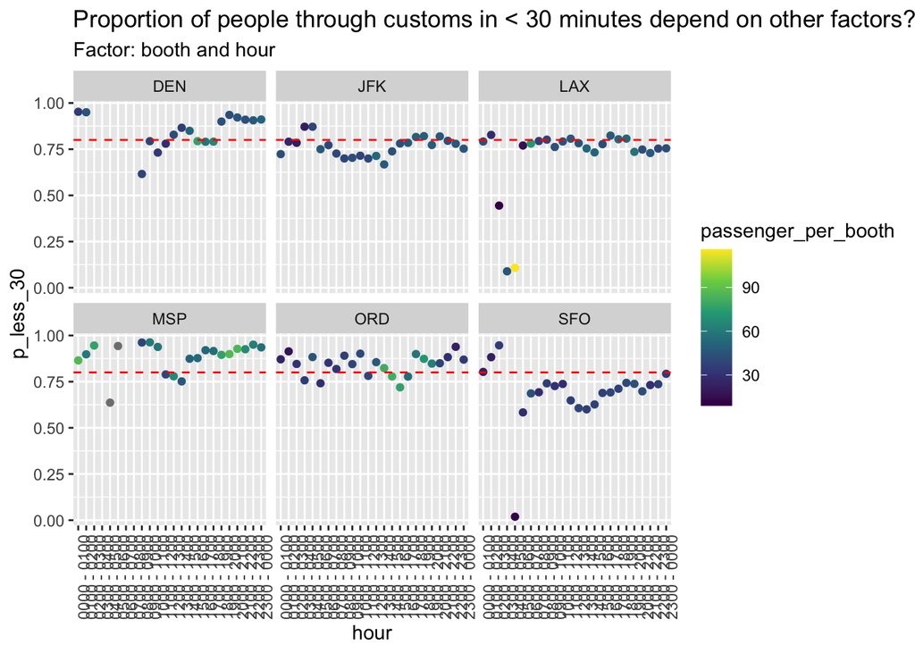

```r
# Look at proportion who wait less than 30 minutes vs. hour
# Color based on proportion number of passengers per booth
awt %>%
  group_by(airport,hour) %>%
  summarize(total = sum(all_total),
            n_less_30 = sum(all_n_0_15) + sum(all_n_16_30),
            p_less_30 = n_less_30 / total,
            booths = sum(all_booths)) %>%
  mutate(passenger_per_booth = total/booths) %>%
  ggplot(aes(hour,p_less_30, color=passenger_per_booth)) +
  geom_point() +
  geom_hline(yintercept = .8, color="red", linetype="dashed")+
  facet_wrap(~airport) +
  theme(axis.text.x = element_text(angle = 90, hjust = 1)) +
  ggtitle("Proportion of people through customs in < 30 minutes depend on other factors?",
          subtitle = "Factor: booth and hour")
```

> Can you think of your own questions to address with this data set?